# mixedFlowR Quick Start: From Design to Scientific Output

mixedFlowR tutorial series

# 1 Purpose

This vignette is the recommended first contact with `mixedFlowR`. It follows one agronomic experiment from the experimental design to a model, diagnostics, inference, a quantitative treatment response, publication-oriented output, and a reproducible report skeleton.

The package is **design-aware** rather than engine-centered. The first question is not “Which function fits a mixed model?” but “What was randomized, to which experimental unit, and which observations share the same source of variation?”

## 1.1 Learning objectives

After completing this vignette, you should be able to:

1. inspect the package capabilities and teaching datasets;
2. audit an experimental design before modeling;
3. understand the transition from legacy split-plot ANOVA to an LMM;
4. fit and diagnose a Gaussian mixed model;
5. obtain small-sample fixed-effect tests when the required backend is available;
6. distinguish qualitative treatment comparisons from quantitative trends;
7. create a table and figure suitable as a starting point for publication;
8. generate a reproducible Markdown report skeleton;
9. recognize when a specialized module is required.

# 2 1. The package workflow

A compact `mixedFlowR` analysis can be remembered as eight questions.

| Question | Typical function |
| --- | --- |
| What is the experimental hierarchy? | `mixed_design_audit()` |
| Is the design balanced and supported? | `mixed_balance()` |
| What model represents that hierarchy? | `mixed_fit()` |
| Did estimation behave properly? | `mixed_diagnose()` |
| What fixed-effect evidence is available? | `mixed_anova()` |
| Is the treatment qualitative or quantitative? | `mixed_emmeans()` / `mixed_trend()` |
| How should results be communicated? | `mixed_table()` / `mixed_plot()` |
| How is the analysis documented? | `mixed_report()` |

The package delegates estimation to established R engines rather than recreating them. `lme4` is the principal core backend for LMMs and GLMMs (Bates et al. 2015); other modules use engines such as `nlme`, `glmmTMB`, `robustlmm`, `gamlss`, `brms`, `SpATS`, and `sommer` when the scientific problem requires their capabilities.

# 3 2. Start by checking capabilities

```r
library(mixedFlowR)

caps <- mixed_capabilities()
caps
```

```
#>         package installed version
#> 1          lme4      TRUE   2.0.6
#> 2          nlme      TRUE 3.1.170
#> 3       glmmTMB      TRUE  1.1.14
#> 4     robustlmm      TRUE 3.5.0.2
#> 5    confintROB      TRUE   1.1.1
#> 6  clubSandwich      TRUE   0.7.0
#> 7      lmerTest      TRUE   3.2.1
#> 8      pbkrtest      TRUE   0.5.5
#> 9       emmeans      TRUE   2.0.4
#> 10       gamlss      TRUE   5.5.0
#> 11  gamlss.dist      TRUE   6.1.1
#> 12         brms      TRUE  2.23.0
#> 13    posterior      TRUE   1.7.0
#> 14          loo      TRUE  2.10.1
#> 15       DHARMa      TRUE   0.5.0
#> 16  performance      TRUE  0.17.1
#> 17 influence.ME      TRUE  0.9.10
#> 18        SpATS      TRUE  1.0.20
#> 19       sommer      TRUE   4.4.6
```

A missing optional package is not automatically an error. It means that the corresponding specialized module is unavailable until that backend is installed.

You can also inspect the 70-block roadmap.

```r
mixed_blocks()
```

```
#>    block                         module            function_name      status
#> 1      1                   Design audit       mixed_design_audit implemented
#> 2      2         Experimental hierarchy          mixed_hierarchy implemented
#> 3      3       Balance and cell support            mixed_balance implemented
#> 4      4       Pseudoreplication screen          mixed_pseudorep implemented
#> 5      5          Legacy split-plot fit     fit_legacy_splitplot implemented
#> 6      6          Expected mean squares            splitplot_ems implemented
#> 7      7        Legacy ANOVA extraction          splitplot_anova implemented
#> 8      8     Legacy-to-mixed comparison     compare_legacy_mixed implemented
#> 9      9               Split-split plot    fit_legacy_splitsplit implemented
#> 10    10                     Strip-plot     fit_legacy_stripplot implemented
#> 11    11              General mixed fit                mixed_fit implemented
#> 12    12              Random intercepts  mixed_random_intercepts implemented
#> 13    13                  Random slopes      mixed_random_slopes implemented
#> 14    14                 Nested effects             mixed_nested implemented
```

[output cut: 56 more lines]

Search by topic:

```r
mixed_blocks("Bootstrap")
```

```
#>   block                       module       function_name      status
#> 1    37             Bootstrap engine          mixed_boot implemented
#> 2    38       Fixed-effect bootstrap    mixed_boot_fixed implemented
#> 3    39 Variance-component bootstrap mixed_boot_variance implemented
#> 4    40         Prediction bootstrap  mixed_boot_predict implemented
```

```r
mixed_blocks("Spatial|field")
```

```
#>   block                     module            function_name      status
#> 1    29   Spatial covariance model mixed_spatial_covariance implemented
#> 2    61       Spatial field trials      mixed_spatial_field implemented
#> 3    62 Spatial surface extraction    mixed_spatial_surface implemented
```

```r
mixed_blocks("GAMLSS|Bayesian")
```

```
#>   block                         module           function_name      status
#> 1    41                   Mixed GAMLSS            mixed_gamlss implemented
#> 2    42    GAMLSS parameter extraction mixed_gamlss_parameters implemented
#> 3    43    GAMLSS comparison/selection     mixed_gamlss_select implemented
#> 4    44   GAMLSS conditional quantiles  mixed_gamlss_quantiles implemented
#> 5    45             GAMLSS diagnostics   mixed_gamlss_diagnose implemented
#> 6    46        Bayesian multilevel fit             mixed_bayes implemented
#> 7    51 Bayesian predictive comparison               mixed_loo implemented
```

# 4 3. Teaching data: a split-plot field experiment

The `splitplot` dataset represents a field trial with blocks, variety as the whole-plot factor, nitrogen dose as the subplot treatment, and yield as the response.

```r
d <- mixed_data("splitplot")
str(d)
```

```
#> 'data.frame':    72 obs. of  4 variables:
#>  $ block   : Factor w/ 6 levels "B1","B2","B3",..: 1 1 1 1 1 1 1 1 1 1 ...
#>  $ variety : Factor w/ 3 levels "V1","V2","V3": 1 1 1 1 2 2 2 2 3 3 ...
#>  $ nitrogen: int  0 50 100 150 0 50 100 150 0 50 ...
#>  $ yield   : num  53.9 62.2 69.3 71.8 59.1 ...
```

```r
head(d)
```

```
#>   block variety nitrogen    yield
#> 1    B1      V1        0 53.92579
#> 2    B1      V1       50 62.24195
#> 3    B1      V1      100 69.33041
#> 4    B1      V1      150 71.76092
#> 5    B1      V2        0 59.14012
#> 6    B1      V2       50 63.76755
```

A first descriptive summary is useful, provided that it is not confused with design-correct inference.

```r
aggregate(yield ~ variety + nitrogen, data = d, FUN = mean)
```

```
#>    variety nitrogen    yield
#> 1       V1        0 49.45760
#> 2       V2        0 54.60099
#> 3       V3        0 47.17976
#> 4       V1       50 56.71933
#> 5       V2       50 61.50809
#> 6       V3       50 54.79277
#> 7       V1      100 61.53654
#> 8       V2      100 67.13670
#> 9       V3      100 57.32322
#> 10      V1      150 64.21728
#> 11      V2      150 68.64470
#> 12      V3      150 61.17077
```

A raw-data plot shows the basic response structure.

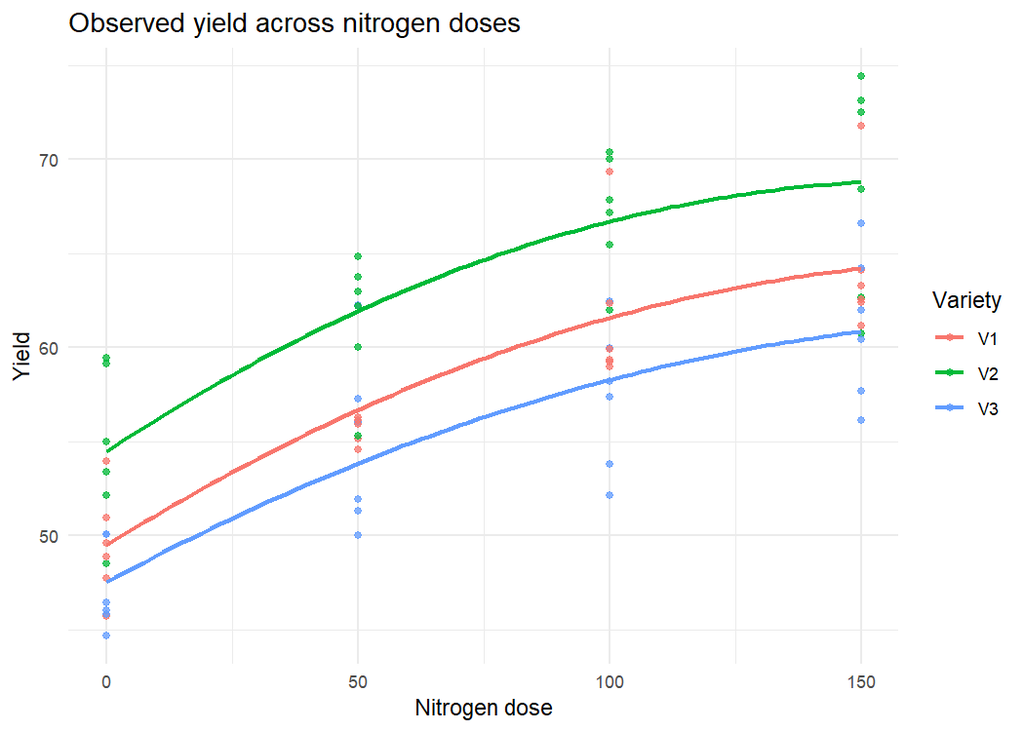

```r
if (requireNamespace("ggplot2", quietly = TRUE)) {
  ggplot2::ggplot(d, ggplot2::aes(nitrogen, yield, group = variety, colour = variety)) +
    ggplot2::geom_point(alpha = 0.75) +
    ggplot2::geom_smooth(method = "lm", formula = y ~ poly(x, 2), se = FALSE) +
    ggplot2::labs(
      x = "Nitrogen dose",
      y = "Yield",
      colour = "Variety",
      title = "Observed yield across nitrogen doses"
    ) +
    ggplot2::theme_minimal(base_size = 11)
}
```

**How to read this figure.** Look for the direction and curvature of the dose response, differences among varieties, unusual observations, and regions with sparse information. The figure does not yet account for the split-plot randomization.

# 5 4. Audit the design before fitting a model

```r
audit <- mixed_design_audit(
  data     = d,
  response = "yield",
  block    = "block",
  whole    = "variety",
  sub      = "nitrogen"
)

audit
```

```
#> $n
#> [1] 72
#>
#> $roles
#>   response      block      whole        sub
#>    "yield"    "block"  "variety" "nitrogen"
#>
#> $balance
#>    block variety nitrogen n
#> 1     B1      V1        0 1
#> 2     B2      V1        0 1
#> 3     B3      V1        0 1
#> 4     B4      V1        0 1
#> 5     B5      V1        0 1
#> 6     B6      V1        0 1
```

[output cut: 169 more lines]

Inspect the declared hierarchy.

```r
mixed_hierarchy(
  d,
  block = "block",
  whole = "variety",
  sub   = "nitrogen"
)
```

```
#> $roles
#>      block      whole        sub
#>    "block"  "variety" "nitrogen"
#>
#> $edges
#>    parent    child              relation
#> 1   block  variety declared nested/order
#> 2 variety nitrogen declared nested/order
```

Inspect treatment support.

```r
mixed_balance(d, c("block", "variety", "nitrogen"))
```

```
#>    block variety nitrogen n
#> 1     B1      V1        0 1
#> 2     B2      V1        0 1
#> 3     B3      V1        0 1
#> 4     B4      V1        0 1
#> 5     B5      V1        0 1
#> 6     B6      V1        0 1
#> 7     B1      V2        0 1
#> 8     B2      V2        0 1
#> 9     B3      V2        0 1
#> 10    B4      V2        0 1
#> 11    B5      V2        0 1
#> 12    B6      V2        0 1
#> 13    B1      V3        0 1
#> 14    B2      V3        0 1
```

[output cut: 58 more lines]

Create an explicit whole-plot identifier and screen for pseudoreplication risk.

```r
d$whole_plot <- interaction(d$block, d$variety, drop = TRUE)

mixed_pseudorep(
  d,
  response  = "yield",
  cluster   = "whole_plot",
  treatment = "variety"
)
```

```
#> $cluster_declared
#> [1] TRUE
#>
#> $counts
#>    cluster treatment n
#> 1    B1.V1        V1 4
#> 2    B2.V1        V1 4
#> 3    B3.V1        V1 4
#> 4    B4.V1        V1 4
#> 5    B5.V1        V1 4
#> 6    B6.V1        V1 4
#> 25   B1.V2        V2 4
#> 26   B2.V2        V2 4
#> 27   B3.V2        V2 4
#> 28   B4.V2        V2 4
#> 29   B5.V2        V2 4
#> 30   B6.V2        V2 4
#> 49   B1.V3        V3 4
#> 50   B2.V3        V3 4
#> 51   B3.V3        V3 4
#> 52   B4.V3        V3 4
#> 53   B5.V3        V3 4
#> 54   B6.V3        V3 4
#>
#> $repeated_within_cluster
#> [1] TRUE
#>
#> $note
#> [1] "Repeated observations within a cluster require an analysis that preserves that dependence; repetition alone does not prove pseudoreplication."
```

## 5.1 Interpretation

The whole plot is the experimental unit for `variety`. Individual subplot observations inside the same whole plot are not independent replicates of the variety treatment. Nitrogen is applied at the subplot level, so it has a different error scale.

# 6 5. Legacy split-plot analysis as a teaching bridge

For a classical balanced analysis, code nitrogen as a factor when the goal is the full split-plot ANOVA decomposition.

```r
d$nitrogen_f <- factor(d$nitrogen)
```

```r
legacy <- fit_legacy_splitplot(
  data     = d,
  response = "yield",
  block    = "block",
  whole    = "variety",
  sub      = "nitrogen_f"
)

splitplot_anova(legacy)
```

```
#>   Df     Sum Sq    Mean Sq     F value       Pr(>F)               term
#> 1  5  513.66467 102.732934          NA           NA          Residuals
#> 2  2  758.64310 379.321549  25.3129410 1.220983e-04          variety
#> 3 10  149.85282  14.985282          NA           NA          Residuals
#> 4  3 2094.21514 698.071714 145.5206532 3.572178e-23 nitrogen_f
#> 5  6   18.59409   3.099015   0.6460235 6.929144e-01 variety:nitrogen_f
#> 6 45  215.86783   4.797063          NA           NA Residuals
#>                stratum
#> 1         Error: block
#> 2 Error: block:variety
#> 3 Error: block:variety
#> 4        Error: Within
#> 5        Error: Within
#> 6        Error: Within
```

Inspect the expected mean-square structure.

```r
splitplot_ems(
  data  = d,
  block = "block",
  whole = "variety",
  sub   = "nitrogen_f"
)
```

```
#>              source df                           expected_mean_square
#> 1             Block  5 sigma_eB^2 + treatment-independent block terms
#> 2 Whole plot factor  2       sigma_eB^2 + whole-plot treatment signal
#> 3  Whole-plot error 10        sigma_eB^2 (block x whole-plot stratum)
#> 4    Subplot factor  3           sigma_e^2 + subplot treatment signal
#> 5       Whole x Sub  6                 sigma_e^2 + interaction signal
#> 6     Subplot error 45                                      sigma_e^2
#>        denominator
#> 1             <NA>
#> 2 Whole-plot error
#> 3             <NA>
#> 4    Subplot error
#> 5    Subplot error
#> 6             <NA>
```

If `lme4` is available, compare the legacy representation with a mixed-model representation.

```r
if (requireNamespace("lme4", quietly = TRUE)) {
  compare_legacy_mixed(
    data     = d,
    response = "yield",
    block    = "block",
    whole    = "variety",
    sub      = "nitrogen_f"
  )
}
```

```
#> $legacy
#>
#> Call:
#> stats::aov(formula = f, data = data)
#>
#> Grand Mean: 58.69065
#>
#> Stratum 1: block
#>
#> Terms:
#>                 Residuals
#> Sum of Squares   513.6647
#> Deg. of Freedom         5
#>
#> Residual standard error: 10.13573
#>
#> Stratum 2: block:variety
#>
#> Terms:
#>                  variety Residuals
#> Sum of Squares  758.6431  149.8528
#> Deg. of Freedom        2        10
#>
#> Residual standard error: 3.871083
#> 6 out of 8 effects not estimable
#> Estimated effects may be unbalanced
#>
#> Stratum 3: Within
#>
#> Terms:
#>                 nitrogen_f variety:nitrogen_f Residuals
#> Sum of Squares   2094.2151            18.5941  215.8678
#> Deg. of Freedom          3                  6        45
#>
#> Residual standard error: 2.19022
#> Estimated effects may be unbalanced
#>
#> $mixed
#> $call
#> NULL
```

[output cut: 143 more lines]

```
#> 4             nitrogen_f50  7.2617342  1.264520
#> 5            nitrogen_f100 12.0789470  1.264520
#> 6            nitrogen_f150 14.7596861  1.264520
#> 7   varietyV2:nitrogen_f50 -0.3546374  1.788302
#> 8   varietyV3:nitrogen_f50  0.3512835  1.788302
#> 9  varietyV2:nitrogen_f100  0.4567622  1.788302
#> 10 varietyV3:nitrogen_f100 -1.9354814  1.788302
#> 11 varietyV2:nitrogen_f150 -0.7159760  1.788302
#> 12 varietyV3:nitrogen_f150 -0.7686759  1.788302
#>
#> $variance
#>             grp        var1 var2     vcov    sdcor
#> 1 block:variety (Intercept) <NA> 2.547064 1.595952
#> 2         block (Intercept) <NA> 7.312720 2.704204
#> 3      Residual        <NA> <NA> 4.797036 2.190214
```

**Interpretation.** The purpose of this comparison is not to declare one paradigm universally superior. In balanced settings, the classical decomposition is a valuable audit and teaching device. The LMM becomes much more useful with imbalance, flexible covariance structures, prediction, random slopes, and extensions to non-Gaussian responses.

# 7 6. Fit the modern LMM

Because nitrogen has a real quantitative scale, return to the numeric variable for the primary trend-oriented analysis.

```r
if (requireNamespace("lme4", quietly = TRUE)) {
  fit <- mixed_fit(
    yield ~ variety * nitrogen +
      (1 | block) +
      (1 | block:variety),
    data = d,
    engine = "lme4"
  )

  fit
}
```

```
#> $call
#> mixed_fit(formula = yield ~ variety * nitrogen + (1 | block) +
#>     (1 | block:variety), data = d, engine = "lme4")
#>
#> $engine
#> [1] "lme4"
#>
#> $model
#> Linear mixed model fit by REML ['lmerMod']
#> Formula: yield ~ variety * nitrogen + (1 | block) + (1 | block:variety)
#>    Data: ..mf_data
#> REML criterion at convergence: 375.5182
#> Random effects:
#>  Groups        Name        Std.Dev.
#>  block:variety (Intercept) 1.464
#>  block         (Intercept) 2.704
#>  Residual                  2.532
#> Number of obs: 72, groups:  block:variety, 18; block, 6
#> Fixed Effects:
#>        (Intercept)           varietyV2           varietyV3            nitrogen
#>          50.618247            5.190415           -2.177139            0.098193
#> varietyV2:nitrogen  varietyV3:nitrogen
#>          -0.002673           -0.009186
#>
#> $data
#>    block variety nitrogen    yield whole_plot nitrogen_f
#> 1     B1      V1        0 53.92579      B1.V1          0
#> 2     B1      V1       50 62.24195      B1.V1         50
#> 3     B1      V1      100 69.33041      B1.V1        100
#> 4     B1      V1      150 71.76092      B1.V1        150
#> 5     B1      V2        0 59.14012      B1.V2          0
#> 6     B1      V2       50 63.76755      B1.V2         50
#> 7     B1      V2      100 70.00531      B1.V2        100
#> 8     B1      V2      150 74.42650      B1.V2        150
#> 9     B1      V3        0 50.05311      B1.V3          0
#> 10    B1      V3       50 56.00415      B1.V3         50
#> 11    B1      V3      100 62.43108      B1.V3        100
#> 12    B1      V3      150 66.58337      B1.V3        150
#> 13    B2      V1        0 45.70060      B2.V1          0
#> 14    B2      V1       50 55.16230      B2.V1         50
```

[output cut: 74 more lines]

```
#>
#>
#> $warnings
#> character(0)
#>
#> $audit
#> $audit$timestamp
#> [1] "2026-08-18 23:52:29.624946"
#>
#> $audit$engine
#> [1] "lme4"
#>
#>
#> attr(,"class")
#> [1] "mixedflow_fit"
```

The random term `(1 | block:variety)` represents variability among whole plots. This is the mixed-model counterpart of the whole-plot error stratum.

# 8 7. Diagnose before interpreting

```r
if (exists("fit")) {
  diag <- mixed_diagnose(fit)
  diag
}
```

```
#> $engine
#> [1] "lme4"
#>
#> $converged
#> [1] TRUE
#>
#> $convergence_messages
#> character(0)
#>
#> $singular
#> [1] FALSE
#>
#> $residuals
#>      fitted    residual
#> 1  55.92744 -2.00165032
```

[output cut: 83 more lines]

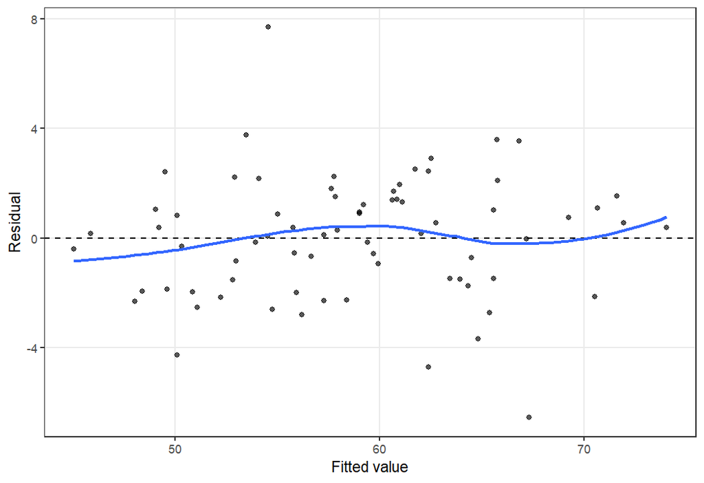

```r
if (exists("fit")) {
  mixed_plot(fit, type = "residuals")
}
```

A useful first checklist is:

- convergence;
- singularity;
- residual pattern;
- extreme residuals;
- evidence of heteroscedasticity;
- unmodeled temporal or spatial dependence, when relevant.

If the diagnostic structure is poor, inference should wait.

# 9 8. Fixed-effect inference

Satterthwaite tests are available when `lmerTest` is installed.

```r
if (
  exists("fit") &&
  requireNamespace("lmerTest", quietly = TRUE)
) {
  mixed_anova(fit, ddf = "Satterthwaite")
}
```

```
#>                       Sum Sq     Mean Sq NumDF    DenDF    F value       Pr(>F)
#> variety           166.245236   83.122618     2 28.07462  12.960982 1.029600e-04
#> nitrogen         1998.250617 1998.250617     1 51.00000 311.579326 2.269203e-23
#> variety:nitrogen    3.348331    1.674165     2 51.00000   0.261046 7.712684e-01
```

Kenward-Roger requires both `lmerTest` and `pbkrtest`.

```r
if (
  exists("fit") &&
  requireNamespace("lmerTest", quietly = TRUE) &&
  requireNamespace("pbkrtest", quietly = TRUE)
) {
  mixed_anova(fit, ddf = "Kenward-Roger")
}
```

```
#>                       Sum Sq     Mean Sq NumDF    DenDF    F value       Pr(>F)
#> variety           166.245236   83.122618     2 28.07464  12.960982 1.029599e-04
#> nitrogen         1998.250617 1998.250617     1 51.00000 311.579326 2.269206e-23
#> variety:nitrogen    3.348331    1.674165     2 51.00000   0.261046 7.712684e-01
```

**Interpretation.** An interaction between variety and nitrogen changes the meaning of the main effects. If the interaction is important, describe how the nitrogen response changes by variety rather than reporting isolated main-effect conclusions.

# 10 9. Qualitative and quantitative questions are different

## 10.1 9.1 Variety as a qualitative treatment

```r
if (
  exists("fit") &&
  requireNamespace("emmeans", quietly = TRUE)
) {
  emm_variety <- mixed_emmeans(
    fit,
    specs = ~ variety
  )

  emm_variety
}
```

```
#>  variety emmean   SE df lower.CL upper.CL
#>  V1        58.0 1.36  8     54.9     61.1
#>  V2        63.0 1.36  8     59.8     66.1
#>  V3        55.1 1.36  8     52.0     58.2
#>
#> Degrees-of-freedom method: kenward-roger
#> Confidence level used: 0.95
```

Planned or pairwise contrasts:

```r
if (
  exists("fit") &&
  requireNamespace("emmeans", quietly = TRUE)
) {
  mixed_contrasts(
    fit,
    specs  = ~ variety,
    method = "pairwise",
    adjust = "tukey"
  )
}
```

```
#>  contrast estimate   SE df t.ratio p.value
#>  V1 - V2     -4.99 1.12 10  -4.465  0.0031
#>  V1 - V3      2.87 1.12 10   2.565  0.0667
#>  V2 - V3      7.86 1.12 10   7.030 <0.0001
#>
#> Degrees-of-freedom method: kenward-roger
#> P value adjustment: tukey method for comparing a family of 3 estimates
```

## 10.2 9.2 Nitrogen as a quantitative treatment

```r
if (
  exists("fit") &&
  requireNamespace("emmeans", quietly = TRUE)
) {
  mixed_trend(
    fit,
    specs = ~ variety,
    var   = "nitrogen"
  )
}
```

```
#>  variety nitrogen.trend      SE df lower.CL upper.CL
#>  V1              0.0982 0.00925 51   0.0796    0.117
#>  V2              0.0955 0.00925 51   0.0770    0.114
#>  V3              0.0890 0.00925 51   0.0704    0.108
#>
#> Degrees-of-freedom method: kenward-roger
#> Confidence level used: 0.95
```

For a curved response, fit a polynomial model explicitly.

```r
if (requireNamespace("lme4", quietly = TRUE)) {
  qfit <- mixed_quantitative(
    data         = d,
    response     = "yield",
    quantitative = "nitrogen",
    qualitative  = "variety",
    group        = "block",
    degree       = 2,
    basis        = "polynomial"
  )
}
```

Then obtain a model-based curve.

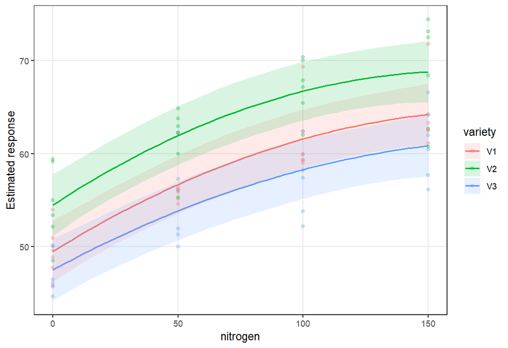

```r
if (
  exists("qfit") &&
  requireNamespace("emmeans", quietly = TRUE)
) {
  mixed_plot(
    qfit,
    type      = "curve",
    x         = "nitrogen",
    by        = "variety",
    values    = seq(min(d$nitrogen), max(d$nitrogen), length.out = 61),
    show_data = TRUE
  )
}
```

**How to read the curve.** The line represents the fitted mean response conditional on the fixed-effect structure, the ribbon represents model uncertainty when supported by the method, and points represent the observations. Focus on biologically meaningful shape and uncertainty, not only the significance of polynomial coefficients.

# 11 10. Create reusable tables

```r
if (exists("fit")) {
  mixed_table(
    fit,
    component = "fixed",
    format    = "markdown",
    digits    = 3,
    caption   = "Fixed-effect estimates for the split-plot LMM"
  )
}
```

Fixed-effect estimates for the split-plot LMM

| term | estimate | std.error |
| --- | --- | --- |
| (Intercept) | 50.618 | 1.524 |
| varietyV2 | 5.190 | 1.487 |
| varietyV3 | -2.177 | 1.487 |
| nitrogen | 0.098 | 0.009 |
| varietyV2:nitrogen | -0.003 | 0.013 |
| varietyV3:nitrogen | -0.009 | 0.013 |

```r
if (exists("fit")) {
  mixed_table(
    fit,
    component = "random",
    format    = "markdown",
    digits    = 3,
    caption   = "Random-effect variance components"
  )
}
```

Random-effect variance components

| grp | var1 | var2 | vcov | sdcor |
| --- | --- | --- | --- | --- |
| block:variety | (Intercept) | NA | 2.143 | 1.464 |
| block | (Intercept) | NA | 7.312 | 2.704 |
| Residual | NA | NA | 6.413 | 2.532 |

# 12 11. Generate a report skeleton

```r
# This writes a new Markdown file in the working directory.
mixed_report(
  fit,
  file  = "quick_start_analysis.md",
  title = "mixedFlowR quick-start analysis"
)
```

This chunk is intentionally not evaluated during vignette building because a package vignette should not create arbitrary files in the build directory.

# 13 12. When to move to a specialized module

| Data or design feature | Next function or vignette |
| --- | --- |
| repeated residual correlation | `mixed_ar1()`, `mixed_car1()` |
| heterogeneous residual variance | `mixed_heterogeneity()` |
| counts / disease incidence | `mixed_count()`, `mixed_binomial()` |
| zero inflation | `mixed_zero_inflated()` |
| influential observations | `mixed_robust()`, `mixed_compare_robust()` |
| asymmetric or difficult uncertainty | `mixed_boot()` |
| distributional scale/shape | `mixed_gamlss()` |
| full posterior inference | `mixed_bayes()` |
| nonlinear biological curves | `mixed_growth()`, `mixed_dose_response()` |
| row-column field trend | `mixed_spatial_field()` |
| genotype by environment | `mixed_met()`, `mixed_gxe()` |

# 14 13. Three quick practice exercises

## 14.1 Exercise 1: incomplete support

Delete one observation and rerun `mixed_balance()`. Which cell becomes incomplete?

```r
d_missing <- d[-1, ]
mixed_balance(d_missing, c("block", "variety", "nitrogen"))
```

```
#>    block variety nitrogen n
#> 1     B2      V1        0 1
#> 2     B3      V1        0 1
#> 3     B4      V1        0 1
#> 4     B5      V1        0 1
#> 5     B6      V1        0 1
#> 6     B1      V2        0 1
#> 7     B2      V2        0 1
#> 8     B3      V2        0 1
#> 9     B4      V2        0 1
#> 10    B5      V2        0 1
#> 11    B6      V2        0 1
#> 12    B1      V3        0 1
#> 13    B2      V3        0 1
#> 14    B3      V3        0 1
```

[output cut: 58 more lines]

## 14.2 Exercise 2: categorical nitrogen

Fit the modern LMM with `nitrogen_f` instead of numeric nitrogen. Compare the scientific question with the trend-based analysis.

```r
if (requireNamespace("lme4", quietly = TRUE)) {
  fit_factor <- mixed_fit(
    yield ~ variety * nitrogen_f +
      (1 | block) +
      (1 | block:variety),
    data = d
  )

  mixed_diagnose(fit_factor)
}
```

```
#> $engine
#> [1] "lme4"
#>
#> $converged
#> [1] TRUE
#>
#> $convergence_messages
#> character(0)
#>
#> $singular
#> [1] FALSE
#>
#> $residuals
#>      fitted    residual
#> 1  55.02458 -1.09879527
```

[output cut: 83 more lines]

## 14.3 Exercise 3: simpler random structure

Fit a model without `(1 | block:variety)` and explain why a smaller AIC, if it occurred, would not by itself justify ignoring the whole-plot randomization.

```r
if (requireNamespace("lme4", quietly = TRUE)) {
  fit_wrong_scale <- mixed_fit(
    yield ~ variety * nitrogen + (1 | block),
    data = d
  )
}
```

# 15 14. Key take-home messages

1. Encode the experimental design before selecting an engine.
2. The random structure should represent real experimental or sampling levels.
3. Diagnostics precede inference.
4. Qualitative and quantitative treatments require different estimands.
5. Report estimates with uncertainty and observed data whenever possible.
6. Specialized backends should be added because the scientific problem requires them, not because they are available.

# 16 15. What to read next

Continue with:

1. `02-design-legacy-splitplot.Rmd` for error strata and classical designs;
2. `03-random-effects-and-shrinkage.Rmd` for random effects and partial pooling;
3. `04-glmm-distributions.Rmd` for non-Gaussian outcomes.

# 17 References

The core mixed-model implementation and the package philosophy build on established mixed-model software and methods, including `lme4` (Bates et al. 2015) and `glmmTMB` (Brooks et al. 2017). Specialized modules are documented in the corresponding focused vignettes.

Bates, Douglas, Martin Maechler, Ben Bolker, and Steve Walker. 2015. “Fitting Linear Mixed-Effects Models Using Lme4.” *Journal of Statistical Software* 67 (1): 1–48. https://doi.org/10.18637/jss.v067.i01.

Brooks, Mollie E., Kasper Kristensen, Koen J. van Benthem, et al. 2017. “glmmTMB Balances Speed and Flexibility Among Packages for Zero-Inflated Generalized Linear Mixed Modeling.” *The R Journal* 9 (2): 378–400. https://doi.org/10.32614/RJ-2017-066.